# Educational Inequality in Australia

Philip Parker

30 October 2014

I have just finished reading [Thomas Piketty’s Capital in the 21st Century](http://www.amazon.com/Capital-Twenty-First-Century-Thomas-Piketty/dp/067443000X).It got me thinking: is the increase in inequality we are observing in wealth (both income and capital) also occurring in education? To explore this I am slowly collating data from historical sources in several countries. Perhaps unsurprisingly, I have made most progress in relation to Australia where I now have data on 15/16 year olds for cohorts born between 1961 to 1997. The older data needs considerable cleaning but today I undertook my first exploration of data covering 1998 to 2012. The questions I wanted to ask were a) have Australian schools become more stratified (i.e., consisting of schools that are increasingly homogeneous in ability levels) and b) has this rise been commensurate with Australia’s slide in Global rankings.

On the surface this may not seem like a reasonable hypothesis. Indeed, Daniele Checchi in his book [The Economics of Education](http://ebooks.cambridge.org/ebook.jsf?bid=CBO9780511492280) notes that there has long been an economic argument in favor of stratification. The argument being such a system is more efficient as teachers can better target their content when students are at a similar levels of ability. While many believe this to be more efficient; Checchi notes that there are concerns that it also increases the gap between higher and lower ability students over time leading to an increase in the divide between the have and have nots in terms of educational attainment.

Indeed, stratification of students by ability may not even be as efficient as classic economics theories suggest. In an article my colleagues and I currently have under review, we show that there is a moderate but negative correlation between the degree to which a country engages in the ability stratification of its students and the ranking of that country in OECD’s Programme for International Student Assessment (PISA).

To test my two questions I used data from the 1998 cohort of the Longitudinal Study of Australian Youth and the 2000, 2003, 2006, 2009, and 2012 PISA international data. Here I focus on the intraclass correlation (ICC) at the school level in math achievement and reading achievement of a total of 70,248 15 year olds. The higher the ICC, the more similar students in the same school are in their achievement levels. An ICC of zero means that students are perfectly randomly assigned to schools, while an ICC of one would mean they are perfectly segregated by academic ability.

Below I plot ICCs in reading and math achievement next to Australia’s ranking in these domains internationally from the year 2000 to 2012 (note there was no international comparison in 1998).

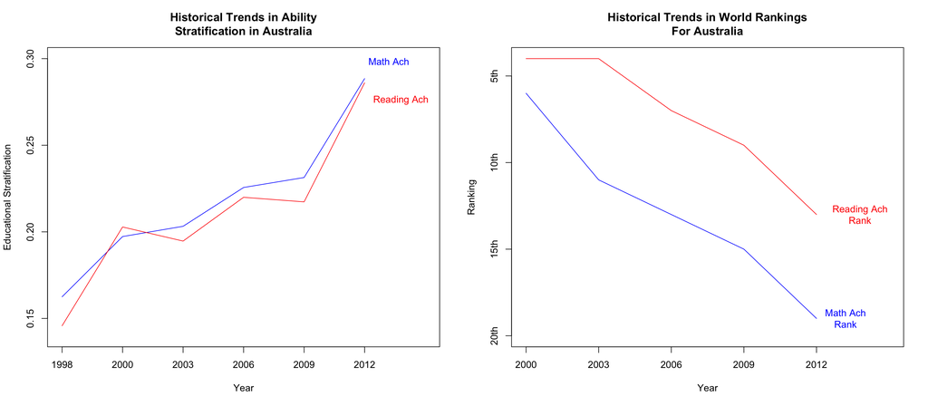

As can be seen there has been a steady increase in ICCs in both math and reading achievement since 1998. This indicates Australia is becoming increasingly stratified by achievement. That is, we are increasingly quarantining our best and our poorest students in separate schools. Interestingly, there is an incredibly strong correlation between increasing stratification in Australia and Australia’s decline in international ranking in math -0.9124 and literacy -0.9336. This may not be causal but merely coincidental but it does suggest a need to look closer at the way we design our educational systems.

Clearly I have a long way to go before I can show that educational inequality growth is mirroring that which Piketty has show for wealth inequality. However, I believe these early signs are concerning and indicate this research needs to be done. While it is quite difficult to draw a clear line between the reasons for the growth in stratification I see here and the growth in wealth inequality seen since World War II. However, Piketty suggests a possible reason in his book. Namely, our increasing obsession with an ill-defined and problematic concepts of ‘meritocracy’ and our strong desire to create and reward superstars.